# Analyse de la Densité et l’hydropériode des étangs - Maîtrise en biologie

Author

Claudie Bouffard

**IMPORTANT:** Les codes suivants ont été générés à l’aide de ChatGPT (GPT-5.6 Luna par OpenAI, 2026) et le support d’Angélique Dupuch et Katrine Turgeon.

## Glossaire

- **PEH :** Plantation de peuplier hybrides sur monticule (entre 1 à 5 ans). Les arbres sont trop jeunes pour avoir un effet sur l’hydrologie par evapotranspiration. Canopée particulièrement ouverte car les arbres sont petits.
- **CPPTM :** Coupe avec Protection des Petites Tiges Marchandes. Similaire à la coupe totale mais certains jeunes arbres sont laissés sur place. Ceux-ci ont tendance à tomber avec le vent. Sur les terres de DOMTAR, cette pratique est majoritairement dans des peuplements résineux mais a été vu dans du feuillus
- **CJ :** Coupe de Jardinage. Coupe qui imite le régime de trouée naturel des forêts de feuillus matures. Cela n’empêche la dégradation du sol par les ornières de machinerie. La canopée reste fermée.
- **NAT:** Étangs vernaux sélectionnées dans des milieux protégés depuis au moins 70 ans. Celui-ci représente le contrôle pour mon étude.Es

## Est-ce que le traitement fait varier le type d’étang observé ?

1. **Préparation des données**

   ```r
   library(readxl)
   library(dplyr)
   library(tidyr)
   df <-read_excel("C:/Users/super/Université du Québec en Outaouais/CLAUDIE ÉTANGS VERNAUX - Documents/Stats/Densité_depression/Data_base_densite.xlsx", sheet = 4)
   df <- df[, c(1,2,3,4,6,8)]
   df[df == "NA"] <- NA
   df <- na.omit(df)
   df$nb_etang_total <- as.numeric(df$nb_etang_total)
   df$orniere <- as.numeric(df$orniere)
   df$trou_monticule <- as.numeric(df$trou_monticule)
   df$naturel <- as.numeric(df$naturel)
   df
   ```

   ```
   # A tibble: 58 × 6
      Transect   Coupe nb_etang_total orniere trou_monticule naturel
      <chr>      <chr>          <dbl>   <dbl>          <dbl>   <dbl>
    1 WATCJ6     CJ                 5       5              0       0
    2 WATCJ5     CJ                 3       3              0       0
    3 WATCJ2     CJ                 2       2              0       0
    4 WATCJ4     CJ                 6       5              0       1
    5 WATCJ3     CJ                 3       3              0       0
    6 WATCPPTM10 CPPTM              0       0              0       0
    7 WATCPPTM11 CPPTM              1       1              0       0
    8 WATCPPTM9  CPPTM              2       2              0       0
    9 WATCPPTM8  CPPTM              0       0              0       0
   10 WATCPPTM13 CPPTM              3       3              0       0
   # ℹ 48 more rows
   ```

2. **Visualisation**

   ```r
   library(ggplot2)
   #Base de donnée pour la visualisation:
   df_plot <- df %>% group_by(Coupe) %>%
     summarise(orniere = sum(orniere),trou_monticule = sum(trou_monticule),naturel = sum(naturel)) %>%
     pivot_longer(cols = c(orniere, trou_monticule, naturel),names_to = "Type_etang",values_to = "Nombre") %>%
     group_by(Coupe) %>%
     mutate(Pourcentage = Nombre / sum(Nombre) * 100)
   df_plot <- df_plot %>% mutate(Type_etang = case_when(Type_etang == "orniere" ~ "Ornière",Type_etang == "trou_monticule" ~ "Trou de monticule", Type_etang == "naturel" ~ "Naturel"))
   df_plot
   ```

   ```
   # A tibble: 9 × 4
   # Groups:   Coupe [3]
     Coupe Type_etang        Nombre Pourcentage
     <chr> <chr>              <dbl>       <dbl>
   1 CJ    Ornière               54       94.7
   2 CJ    Trou de monticule      0        0
   3 CJ    Naturel                3        5.26
   4 CPPTM Ornière               89       75.4
   5 CPPTM Trou de monticule      0        0
   6 CPPTM Naturel               29       24.6
   7 PEH   Ornière               27        7.61
   8 PEH   Trou de monticule    328       92.4
   9 PEH   Naturel                0        0
   ```

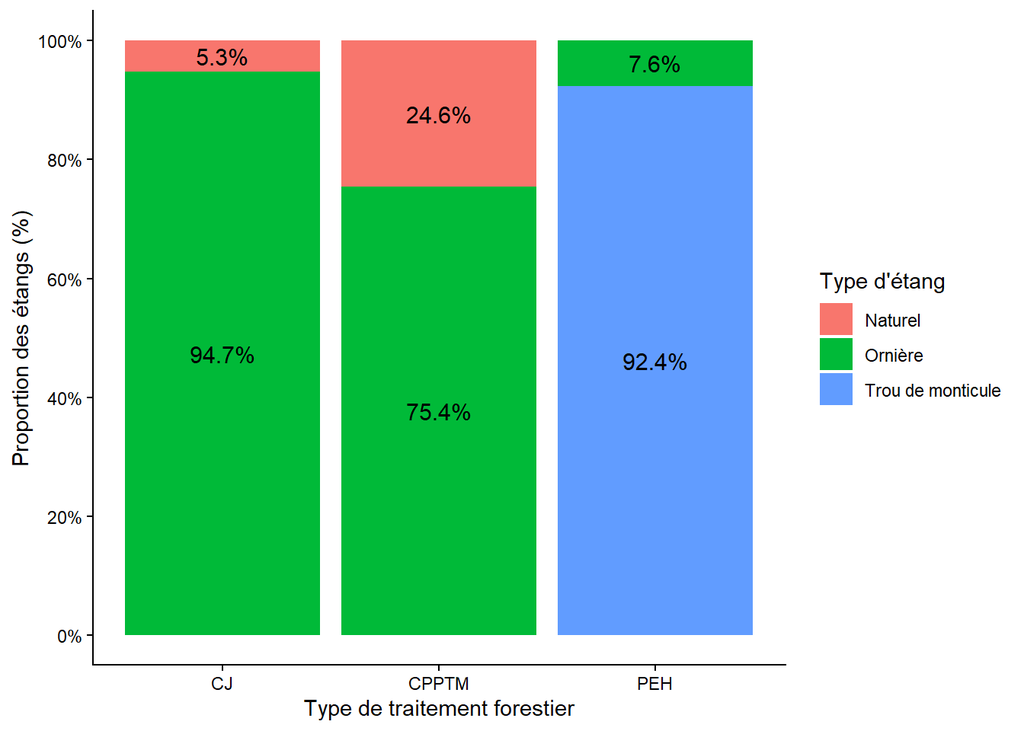

   ```r
   #Visualisation
   ggplot(df_plot, aes(x = Coupe, y = Pourcentage, fill = Type_etang)) +
     geom_col() +
     geom_text(aes(label = ifelse(Pourcentage == 0,"",paste0(round(Pourcentage, 1), "%"))),position = position_stack(vjust = 0.5),size = 4) +
     scale_y_continuous(limits = c(0, 100),breaks = seq(0, 100, 20),labels = function(x) paste0(x, "%")) +
     labs(x = "Type de traitement forestier", y = "Proportion des étangs (%)",fill = "Type d'étang") +
     theme_classic()
   ```

   (J’ai dut retiré beaucoup d’info manquante (NA) ce qui explique pourquoi mes ‘’n’’ sont plus bas que les autres analyses)

   Pourquoi est-ce qu’ici il n’y a pas de données pour NAT (forêts matures) ? C’est parce que le type d’étang a été compté seulement en mai et non en avril. Ainsi, en mai, tous les étangs comptés dans NAT étaient secs. Par contre, par logique, c’est certain que 100% des NAT étaient de type naturel puisque j’ai choisi des peuplement sans trace d’exploitation forestière visible.
3. **Conclusion :**

   Il semblerait que lorsque la forêt est exploitée sans travail du sol (e.g. créations de trous comme pour les plantations sur monticules), l’eau semble surtout s’accumuler dans les ornières. Ainsi, la disponibilité en type d’étang pour les amphibiens semble complètement changé par les ornières laissées par la machinerie. Ici, il est clair que le traitement forestier va faire varier le type d’étang disponible pour les amphibiens.

## Est-ce que le type d’étang change la possibilité de sécheresse?

La litérature suggère que les étangs dans les ornières sont des pièges écologiques pour les amphibiens. Puisque l’analyse ci-haut a révélé qu’une grande quantité des étangs disponibles sont des ornières, il serait intéressant de voir si ceux-ci sèchent effectivement plus vite que les autres. Particulièrement puisque nous avons suivi plusieurs étangs de chaque type pendant plusieurs mois. Il est certain que le moment que l’étang a séché n’est pas précisé (ce n’est pas parce qu’un étang sèche à un point que c’est ‘’mauvais’’, juste QUAND il sèche selon le cycle de vie des amphibiens est important), par contre, l’exploration du sujet reste pertinant.

1. **Préparation des données :**

   ```r
   df <- read_excel("C:/Users/super/Université du Québec en Outaouais/CLAUDIE ÉTANGS VERNAUX - Documents/Stats/Densité_depression/Bases_de_donnees/Data_Base_presenceV7.xlsx", sheet = 6)
   df$Sec <- ifelse(df$Hydro == "sec", 1, 0)
   df$Type_etang <- factor(df$Type_etang)
   df
   ```

   ```
   # A tibble: 57 × 5
      No_etang   Hydro Type_etang Coupe   Sec
      <chr>      <chr> <fct>      <chr> <dbl>
    1 1WATCJ6    hum   orniere    CJ        0
    2 2WATCJ5    hum   orniere    CJ        0
    3 3WATCJ1    sec   orniere    CJ        1
    4 4WATCJ2    sec   orniere    CJ        1
    5 5WATCJ4    hum   orniere    CJ        0
    6 6WATCJ3    sec   orniere    CJ        1
    7 17WATPEH10 hum   orniere    PEH       0
    8 7WATPEH2   hum   trou       PEH       0
    9 12WATPEH5  hum   trou       PEH       0
   10 8WATPEH1   hum   trou       PEH       0
   # ℹ 47 more rows
   ```

2. **Choix de l’analyse :**

   Pour ce type d’analyse, un glm binomial (sec ou non) serait intéressant. Toutefois, il faut s’assurer que nos données fonctionne bien avec ce type de modèle

   ```r
   library(detectseparation)
   mod_hydro <- glm(Sec ~ Type_etang,family = binomial,data = df)
   check_sep <- update(mod_hydro,method = "detect_separation")
   check_sep
   ```

   ```
   Implementation: ROI | Solver: lpsolve
   Separation: TRUE
   Existence of maximum likelihood estimates
         (Intercept) Type_etangorniere    Type_etangtrou
                   0                 0              -Inf
   0: finite value, Inf: infinity, -Inf: -infinity
   ```

   Clairement il y a un problème ! Une séparation complète (en effet, aucun des étangs dans les plantations sur monticules ont séchés.) Donc, il faut appliquer la correction brglmFit

   ```r
   library(brglm2)
   mod_hydro <- glm( Sec ~ Type_etang,family = binomial,data = df, method = "brglmFit")
   ```

   Maintenant, on peut tester si ce modèle est bon

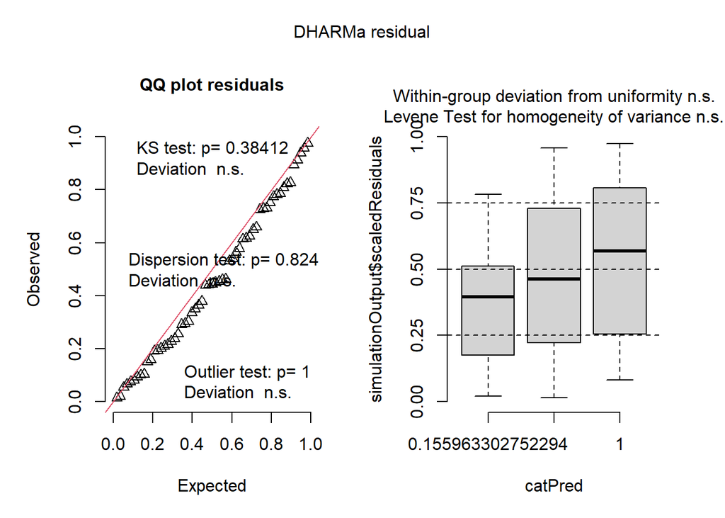

   ```r
   library(DHARMa)
   res <- simulateResiduals(mod_hydro)
   plot(res) #très beau
   ```

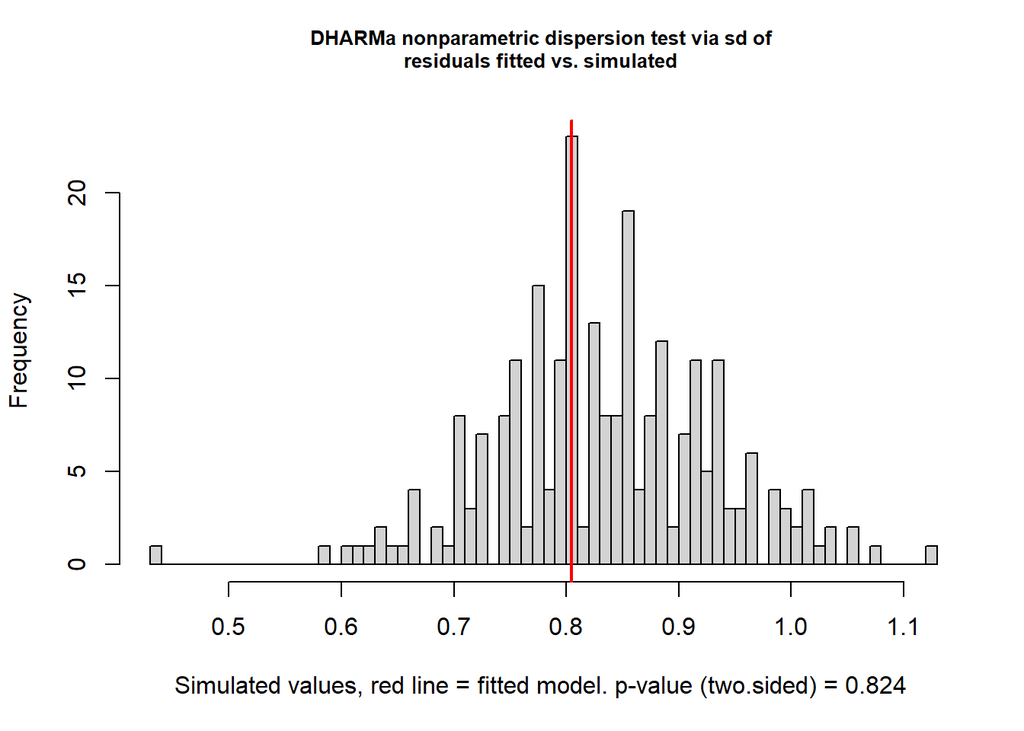

   ```
       DHARMa nonparametric dispersion test via sd of residuals fitted vs.
       simulated

   data:  simulationOutput
   dispersion = 0.96315, p-value = 0.824
   alternative hypothesis: two.sided
   ```

   ```r
   testDispersion(res)
   ```

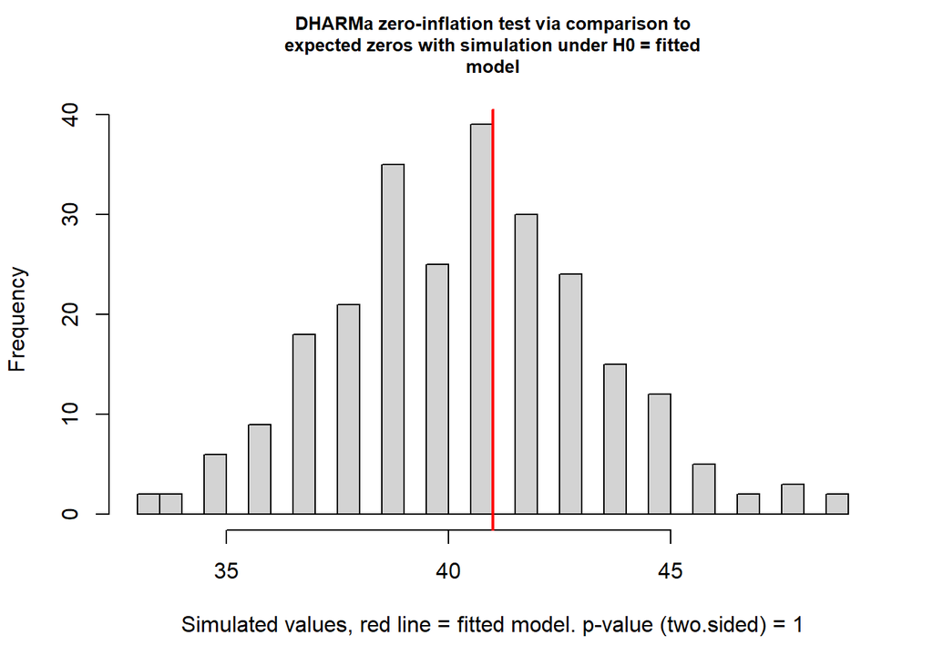

   ```
       DHARMa zero-inflation test via comparison to expected zeros with
       simulation under H0 = fitted model

   data:  simulationOutput
   ratioObsSim = 1.0095, p-value = 1
   alternative hypothesis: two.sided
   ```

   ```r
   testZeroInflation(res)
   ```

   Très beau, on peut faire l’analyse
3. **Analyse**

   À noter ici que pairwise fonctionne mal avec brglmFit. donc, va falloir relevel pour comparer la significativité entre les types d’étangs

   ```r
   library(emmeans)
   summary(mod_hydro)
   ```

   ```
   Call:
   glm(formula = Sec ~ Type_etang, family = binomial, data = df,
       method = "brglmFit")

   Deviance Residuals:
       Min       1Q   Median       3Q      Max
   -1.4350  -0.9236  -0.2444   0.9400   1.4545

   Coefficients:
                     Estimate Std. Error z value Pr(>|z|)
   (Intercept)         0.5878     0.8520   0.690   0.4903
   Type_etangorniere  -1.2191     0.9230  -1.321   0.1866
   Type_etangtrou     -4.0843     1.7074  -2.392   0.0168 *
   ---
   Signif. codes:  0 '***' 0.001 '**' 0.01 '*' 0.05 '.' 0.1 ' ' 1

   (Dispersion parameter for binomial family taken to be 1)

       Null deviance: 67.676  on 56  degrees of freedom
   Residual deviance: 53.615  on 54  degrees of freedom
   AIC:  59.615

   Type of estimator: AS_mixed (mixed bias-reducing adjusted score equations)
   Number of Fisher Scoring iterations: 7
   ```

   ```r
   df$Type_etang <- relevel(df$Type_etang, ref = "orniere")
   mod_hydro2 <- glm(Sec ~ Type_etang,family = binomial,data = df,method = "brglmFit")
   summary(mod_hydro2)
   ```

   ```
   Call:
   glm(formula = Sec ~ Type_etang, family = binomial, data = df,
       method = "brglmFit")

   Deviance Residuals:
       Min       1Q   Median       3Q      Max
   -1.4350  -0.9236  -0.2444   0.9400   1.4545

   Coefficients:
                     Estimate Std. Error z value Pr(>|z|)
   (Intercept)        -0.6313     0.3550  -1.778   0.0754 .
   Type_etangnaturel   1.2191     0.9230   1.321   0.1866
   Type_etangtrou     -2.8652     1.5217  -1.883   0.0597 .
   ---
   Signif. codes:  0 '***' 0.001 '**' 0.01 '*' 0.05 '.' 0.1 ' ' 1

   (Dispersion parameter for binomial family taken to be 1)

       Null deviance: 67.676  on 56  degrees of freedom
   Residual deviance: 53.615  on 54  degrees of freedom
   AIC:  59.615

   Type of estimator: AS_mixed (mixed bias-reducing adjusted score equations)
   Number of Fisher Scoring iterations: 7
   ```

   ```r
   emmeans(mod_hydro, ~ Type_etang, type = "response")
   ```

   ```
    Type_etang   prob     SE  df asymp.LCL asymp.UCL
    naturel    0.6429 0.1960 Inf   0.25310     0.905
    orniere    0.3472 0.0805 Inf   0.20963     0.516
    trou       0.0294 0.0422 Inf   0.00166     0.355

   Confidence level used: 0.95
   Intervals are back-transformed from the logit scale
   ```

| Type d’étang | Chance de sécher durant l’année |
| --- | --- |
| Naturel | 64.29 % |
| Ornière | 34.72 % |
| Trous des plantations sur monticules | 2.94 % |

Le intercept de mod_hydro représente les étangs de types ‘naturels’. Selon cette analyse, les ornières ne sècheraient pas significativement plus rapidement que les étangs des dépressions naturelels. Par contre, pour réellement rejetté le concepte de piège écologique mentionné dans la litérature, il va falloir voir le **moment** de la sécherresse (est-ce que les ornières sèchent AVANT ou APRÈS la métamorphose).  
Sur un autre sujet, les étangs dans les trous de plantations sur monticules sèchent significativement moins rapidement que ceux naturels. Plus encore, si on compare les ornières avec les trous des plantations à l’aide de mod_hydro2, on voit que la différence n’est pas significatif…mais PRESQUE. Probablement avec plus d’échantillons, ce serait significatif.

4. **Visualisation**

   ```r
   pred_hydro <- as.data.frame(emmeans(mod_hydro, ~ Type_etang, type = "response"))
   pred_hydro$Type_etang <- as.character(pred_hydro$Type_etang)
   pred_hydro$Type_etang[pred_hydro$Type_etang == "trou"] <- "trou de monticule"
   pred_hydro$Type_etang[pred_hydro$Type_etang == "orniere"] <- "ornière"
   pred_hydro
   ```

   ```
    Type_etang             prob         SE  df  asymp.LCL asymp.UCL
    naturel           0.6428571 0.19561521 Inf 0.25310351 0.9053127
    ornière           0.3472222 0.08047341 Inf 0.20963267 0.5161437
    trou de monticule 0.0294118 0.04223943 Inf 0.00166446 0.3551615

   Confidence level used: 0.95
   Intervals are back-transformed from the logit scale
   ```

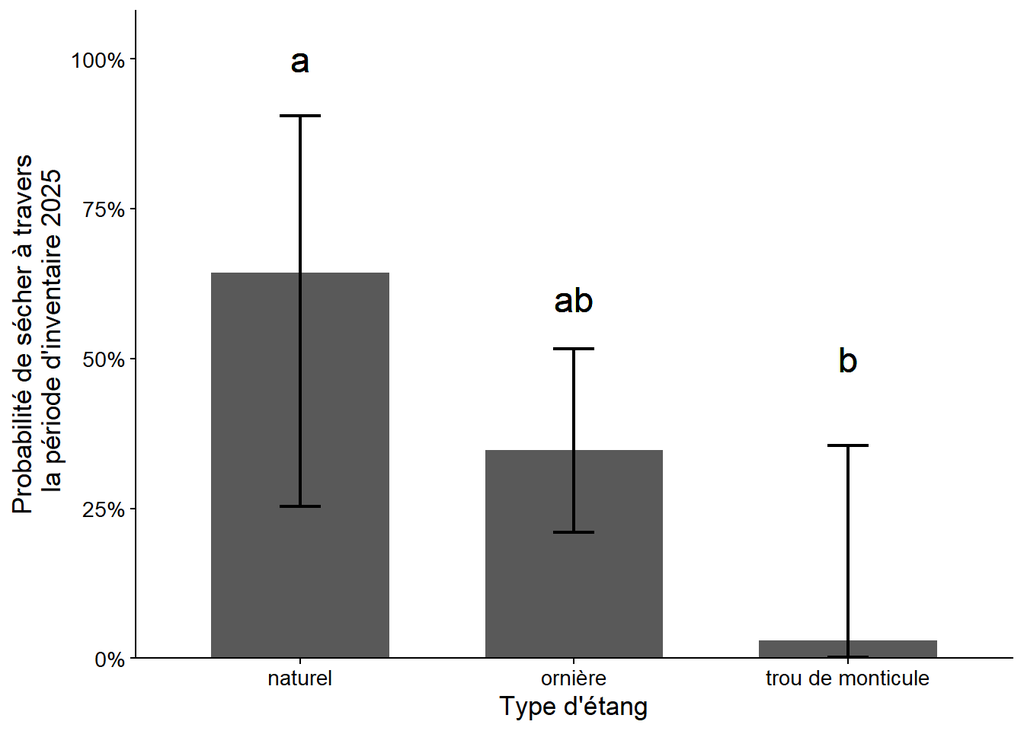

   ```r
   ggplot(pred_hydro, aes(x = Type_etang, y = prob)) +
     geom_col(width = 0.65) +
     geom_errorbar(aes(ymin = asymp.LCL, ymax = asymp.UCL),width = 0.15,linewidth = 0.8) +
     geom_text(aes(x = 1, y = 1, label = "a"),size = 6) + # Naturel
     geom_text(aes(x = 2, y = 0.60, label = "ab"),size = 6) + # ornière
     geom_text(aes(x = 3, y = 0.50, label = "b"),size = 6) + # Trou monticule
     scale_y_continuous(labels = scales::percent,limits = c(0, 1),expand = expansion(mult = c(0, 0.08))) +
     labs(x = "Type d'étang",
       y = "Probabilité de sécher à travers\n la période d'inventaire 2025") +
     theme_classic() +
     theme(text = element_text(size = 13))
   ```

n Naturel = 6, n Ornière = 35 , n Trou de monticule = 16

## Es-ce que les étangs d’ornières sèchent plus rapidement que les étangs naturels?

Cette question découle directement de l’analyse précédente. La littérature mentionne que les ornières sont un piège écologique pour les amphibiens dépendant des étangs vernaux. Pourtant, l’analyse ci-haut estime que les étangs d’ornières ne sècheraient pas significativement plus que les étangs naturels. Mais, pour les amphibiens dépendant des étangs vernaux, un des choses les plus importantes est le temps! Ainsi, il est nécessaire de voir si les étangs d’ornières sèchent plus rapidement ou non que les étangs naturels afin de réellement pouvoir évaluer si ceux-ci ont un potentiel d’être un piège écologique.

1. **Préparation des données**

   Ici, je crois qu’un modèle de Fine-Gray pourrait bien représenter le concepte que je veux explorer. Il permet de prendre en compte le temps, ainsi que l’effet compétitif entre un étang qui sèche et un étang qui reste humide (e.g. si un étang reste humide jusqu’à la métamorphose, c’est certain qu’il ne pourra pas sécher ‘’prématurément’’ par après). De plus, j’ai aussi de la cencure à droit qui peut être concidéré par ce modèle.  
   Par contre, il faut bien préparer les données en conséquence de ce type d’analyse

   ```r
   df <-read_excel("C:/Users/super/Université du Québec en Outaouais/CLAUDIE ÉTANGS VERNAUX - Documents/Stats/Densité_depression/Bases_de_donnees/TYPE_FineGray_PoolSpecific_Database.xlsx", sheet = 1)
   df <- df %>%filter(Type_etang != "trou")
   df$Type_etang <- factor(df$Type_etang,levels = c("naturel", "orniere"))
   df[df == "NA"] <- NA
   df$Der_prise <- as.numeric(df$Der_prise)
   df$Type_etang <- factor(df$Type_etang)
   df$Type_etang <- relevel(df$Type_etang, ref = "naturel")
   df$Temps_milieu <- ifelse(is.na(df$Der_prise),df$AvantDer_prise,(df$AvantDer_prise + df$Der_prise) / 2)
   df
   ```

   ```
   # A tibble: 41 × 8
      No_etang     Type_etang AvantDer_prise Der_prise Statut Condition Traitements
      <chr>        <fct>               <dbl>     <dbl>  <dbl> <chr>     <chr>
    1 1WATCJ6      orniere                37        NA      3 ind       CJ
    2 2WATCJ5      orniere                37        NA      3 ind       CJ
    3 3WATCJ1      orniere                51        61      1 mort      CJ
    4 4WATCJ2      orniere               110       127      1 mort      CJ
    5 5WATCJ4      orniere                93        NA      2 meta      CJ
    6 6WATCJ3      orniere               110       128      1 mort      CJ
    7 17WATPEH10   orniere                50        NA      3 ind       PEH
    8 15WATCPPTME… orniere                50        NA      3 ind       CPPTM
    9 11WATCPPTM1  orniere                80        NA      2 meta      CPPTM
   10 10WATCPPTM5  orniere                92        NA      0 ind       CPPTM
   # ℹ 31 more rows
   # ℹ 1 more variable: Temps_milieu <dbl>
   ```

Pour cette analyse, on a besoin d’un code pour chaque situation. Donc, voici celui que j’ai utilisé:

| Code | Signification | Rôle |
| --- | --- | --- |
| 1 | Sécheresse avant la métamorphose | Évènement d’intérêt |
| 2 | Humide assez longtemps pour permettre la métamorphose | Risque compétitif |
| 3 | Indéterminé (disparition des amphibiens sans savoir la cause. L’inventaire a été arrêté) | Risque compétitif |
| 0 | Resté humide jusqu’à la fin de la prise de l’inventaire sans que les amphibiens ne se soient tous métamorphosés | Censure à droite |

Note la ligne suivante: ‘’df$Temps_milieu <- ifelse(is.na(df$Der_prise),df$AvantDer_prise,(df$AvantDer_prise + df$Der_prise) / 2)’’. Pour un modèle de Fine-Gray, il faut une date précise pour déterminer quand l’évènement c’est passé. Par contre, je n’ai pas surveillé les étangs à chaque jours. Donc, choisir la date entre l’avant dernière observation et la dernière observation est le meilleurs compromis.

2. **Analyse**

   ```r
   library(cmprsk)
   Type <- model.matrix(~ Type_etang, data = df)[, -1]
   FG_type <- crr(ftime = df$Temps_milieu,fstatus = df$Statut,cov1 = Type,
                   failcode=1,cencode=0)
   summary(FG_type)
   ```

   ```
   Competing Risks Regression

   Call:
   crr(ftime = df$Temps_milieu, fstatus = df$Statut, cov1 = Type,
       failcode = 1, cencode = 0)

           coef exp(coef) se(coef)      z p-value
   Type1 -0.343      0.71    0.593 -0.578    0.56

         exp(coef) exp(-coef)  2.5% 97.5%
   Type1      0.71       1.41 0.222  2.27

   Num. cases = 41
   Pseudo Log-likelihood = -51.6
   Pseudo likelihood ratio test = 0.26  on 1 df,
   ```

Cette analyse révèle qu’il ne semble pas avoir de différence significative entre ‘’ornière’’ et ‘’naturel’’.

3. **Visualisation**

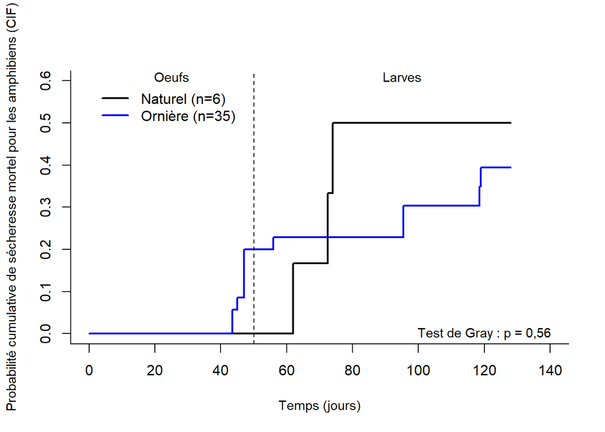

   ```r
   cif <- with(df,cuminc(ftime = Temps_milieu,fstatus = Statut,group = Type_etang))

   plot(cif[c("naturel 1", "orniere 1")],lwd = 2,lty = c(1, 1),col = c("black", "blue"),xlab = "Temps (jours)",ylab = "Probabilité cumulative de sécheresse mortel pour les amphibiens (CIF)",
        cex.lab = 0.9, xlim = c(0, 140),ylim = c(0, 0.6),curvlab = NA,xaxt = "n")
   # Axe des X
   axis(side = 1,at = seq(0, 140, by = 20))
   # Légende
   legend(x = 0,y = 0.6,legend = c("Naturel (n=6)", "Ornière (n=35)"),col = c("black", "blue"),lwd = 2,box.lty = 0)
   abline(v = 50, lty = 2)
   text(x = 120,y = 0,labels = "Test de Gray : p = 0,56",cex = 0.9)
   text(x = 25,y = 0.61,labels = "Oeufs",cex = 0.9)
   text(x = 95,y = 0.61,labels = "Larves",cex = 0.9)
   ```

n naturel = 6, n ornière = 35

À noter qu’il semblerait que les étangs naturels sèchent un peu plus vite malgré le manque de significativité statistique. Puisque le n de naturel est très bas (n=6), il est difficile de déterminer la réelle tendance sans prendre en concidération qu’il y a une forte incertitude.

4. **Conclusion:**

   Mes analyses semblent aller en l’encontre de la littérature. Les ornières ne semblent pas sécher plus rapidement que les étangs naturels. Mes données vont donc en l’encontre de la théorie que les ornières seraient des pièges écologiques pour les amphibiens dépendant des étangs vernaux lorsque comparé aux étangs naturel. Ce qui est important à prendre en compte ici c’est qu’il y a très peu de littérature sur cet exacte sujet. La science est encore en développement lorsque ça touche à l’impact des ornières sur les amphibiens. De plus, mes n ne sont pas si élevé, donc plus d’études serait nécessaire pour confirmer le point apportée par mes données.  
   Toutefois, d’après ce que j’ai présentement, les ornières ne semblent pas particulièrement être problématique pour les amphibiens, malgré le fait qu’il y en a maintenant plus que les étang naturel dans les forêts exploités.

## AVRIL: Est-ce que la densité d’étang/ha varie entre les traitements ?

**1.1 Préparation des données :**

```r
setwd('C:/Users/super/Université du Québec en Outaouais/CLAUDIE ÉTANGS VERNAUX - Documents/Stats/Densité_depression/Bases_de_donnees')
library(readxl)

df <-read_excel("C:/Users/super/Université du Québec en Outaouais/CLAUDIE ÉTANGS VERNAUX - Documents/Stats/Densité_depression/Data_base_densite.xlsx", sheet = 1)
df$Coupe <- as.factor(df$Coupe)
df$nb_etang_total <- as.numeric(df$nb_etang_total)
df <- df[-8, ]
df
```

```
# A tibble: 85 × 14
   Transect   Coupe nb_etang_total orniere orniere_coloni trou_monticule
   <chr>      <fct>          <dbl> <chr>   <chr>          <chr>
 1 WATCJ6     CJ                 9 7       NA             0
 2 WATCJ5     CJ                 3 3       NA             0
 3 WATCJ1     CJ                 0 0       NA             0
 4 WATCJ2     CJ                 1 1       NA             0
 5 WATCJ4     CJ                10 9       NA             0
 6 WATCJ3     CJ                 2 2       NA             0
 7 WATCPPTM10 CPPTM              2 2       NA             0
 8 WATCPPTM9  CPPTM              1 1       NA             0
 9 WATCPPTM8  CPPTM              1 1       NA             0
10 WATCPPTM7  CPPTM              1 1       NA             0
# ℹ 75 more rows
# ℹ 8 more variables: trou_coloni <chr>, naturel <chr>, naturel_colo <chr>,
#   nb_colonise_total <chr>, LISY <chr>, AMMA <chr>, LICL <chr>,
#   anoure_sp <chr>
```

```r
den_a <- df[, c(2, 3)]
den_a
```

```
# A tibble: 85 × 2
   Coupe nb_etang_total
   <fct>          <dbl>
 1 CJ                 9
 2 CJ                 3
 3 CJ                 0
 4 CJ                 1
 5 CJ                10
 6 CJ                 2
 7 CPPTM              2
 8 CPPTM              1
 9 CPPTM              1
10 CPPTM              1
# ℹ 75 more rows
```

```r
table(df$nb_etang_total)
```

```
 0  1  2  3  4  5  6  7  8  9 10 11 12 13 15 17 18 20 23 24 26 28 30 33 34 37
16 14 10  3  6  4  2  3  2  4  3  1  1  1  1  1  1  1  1  1  2  2  1  1  1  1
40
 1
```

*Note: ici, le décompte n’est pas ‘’étangs/ha’’ puisque cette base de donnée était difficilement ajustable à un modèle. Ainsi, un décompte brut a été utilisé pour cette analyse. Le décompte brut a été effectué dans des transects de 200m2.

**1.2 Choix de l’analyse**

```r
mod1 <- aov(den_a$nb_etang_total ~ den_a$Coupe)
shapiro.test(residuals(mod1))
```

```
    Shapiro-Wilk normality test

data:  residuals(mod1)
W = 0.93978, p-value = 0.00062
```

Le résultat est significatif ! Les données ne sont pas du tout normales

```r
library(car)
leveneTest(den_a$nb_etang_total ~ den_a$Coupe)
```

```
Levene's Test for Homogeneity of Variance (center = median)
      Df F value  Pr(>F)
group  3  18.951 2.1e-09 ***
      81
---
Signif. codes:  0 '***' 0.001 '**' 0.01 '*' 0.05 '.' 0.1 ' ' 1
```

Aussi significatif ! Les données ne sont pas homogène non plus

```r
mod2 <- glm(den_a$nb_etang_total ~ den_a$Coupe,family = poisson(link = "log"))
dis <- sum(residuals(mod2, type = "pearson")^2) / df.residual(mod2)
dis
```

```
[1] 5.088833
```

la dispersion est plus de 2, c’est trop élevé! Un GLM Poisson est innaproprié ici.

Avec ces limitations, va falloir procéder avec un modèle binomial négatif.

```r
library(MASS)
mod3 <- glm.nb(den_a$nb_etang_total ~ den_a$Coupe)
```

Il est préférable de faire un test DHARMa pour s’assurer que ce modèle est bien fiable avant de continuer avec l’interprétation.

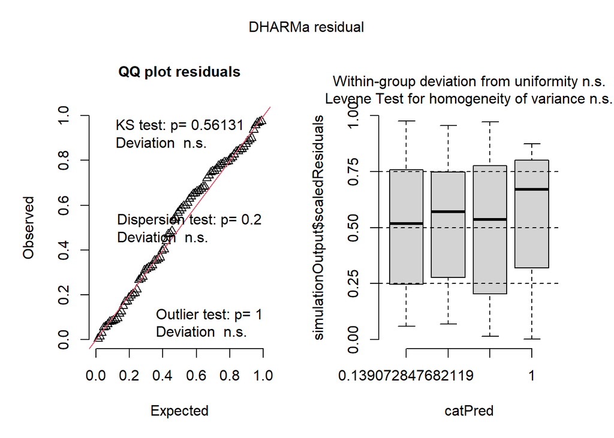

```r
library(DHARMa)
mod3 <- glm.nb(den_a$nb_etang_total ~ den_a$Coupe)
sim <- simulateResiduals(mod3)
plot(sim)
```

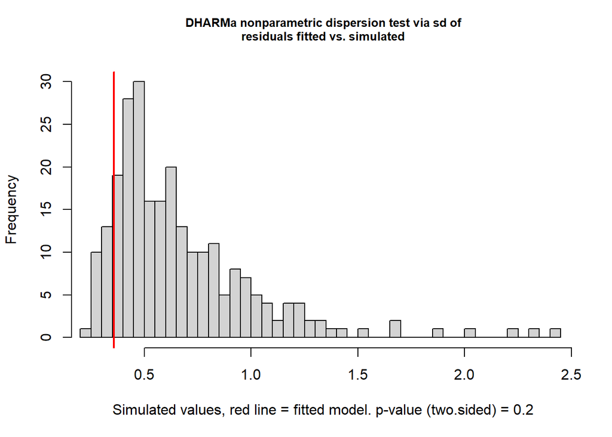

```
    DHARMa nonparametric dispersion test via sd of residuals fitted vs.
    simulated

data:  simulationOutput
dispersion = 0.5346, p-value = 0.2
alternative hypothesis: two.sided
```

```r
testDispersion(sim) #ok
```

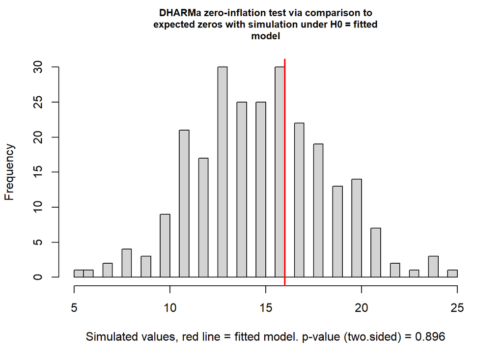

```
    DHARMa zero-inflation test via comparison to expected zeros with
    simulation under H0 = fitted model

data:  simulationOutput
ratioObsSim = 1.0644, p-value = 0.896
alternative hypothesis: two.sided
```

```r
testZeroInflation(sim) #ok
```

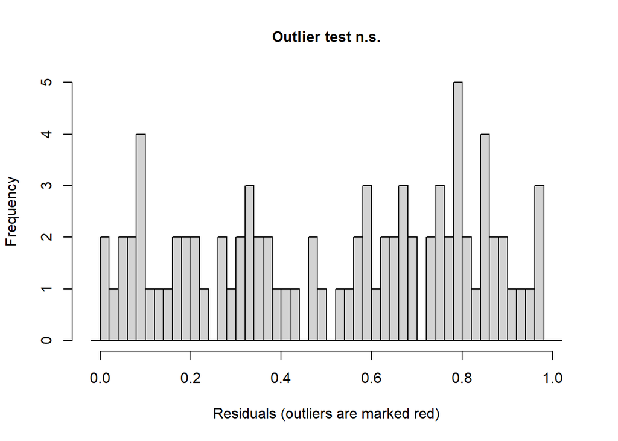

```
    DHARMa bootstrapped outlier test

data:  sim
outliers at both margin(s) = 0, observations = 85, p-value = 1
alternative hypothesis: two.sided
 percent confidence interval:
 0.00000000 0.02352941
sample estimates:
outlier frequency (expected: 0.00529411764705882 )
                                                 0
```

```r
testOutliers(sim) #ok
```

Les résultats sont beau, on peut continuer l’analyse

**1.3 Analyse : Modèle Binomial négatif**

```r
mod3 <- glm.nb(den_a$nb_etang_total ~ den_a$Coupe)
anova(mod3, test = "Chisq")
```

```
Analysis of Deviance Table

Model: Negative Binomial(1.2039), link: log

Response: den_a$nb_etang_total

Terms added sequentially (first to last)

            Df Deviance Resid. Df Resid. Dev  Pr(>Chi)
NULL                           84    164.346
den_a$Coupe  3   68.228        81     96.119 1.022e-14 ***
---
Signif. codes:  0 '***' 0.001 '**' 0.01 '*' 0.05 '.' 0.1 ' ' 1
```

C’est significatif, au moins un traitement sylvicole a une densité d’étang qui diffère des autres.

**1.4 Post-Hoc : Emmeans**

```r
library(emmeans)
emmeans(mod3, pairwise ~ Coupe, adjust = "tukey")
```

```
$emmeans
 Coupe emmean    SE  df asymp.LCL asymp.UCL
 CJ     1.447 0.231 Inf     0.994     1.899
 CPPTM  1.656 0.202 Inf     1.260     2.052
 NAT    0.336 0.278 Inf    -0.208     0.881
 PEH    2.978 0.210 Inf     2.567     3.390

Results are given on the log (not the response) scale.
Confidence level used: 0.95

$contrasts
 contrast    estimate    SE  df z.ratio p.value
 CJ - CPPTM    -0.209 0.307 Inf  -0.682  0.9038
 CJ - NAT       1.110 0.361 Inf   3.073  0.0114
 CJ - PEH      -1.531 0.312 Inf  -4.907 <0.0001
 CPPTM - NAT    1.320 0.344 Inf   3.841  0.0007
 CPPTM - PEH   -1.322 0.291 Inf  -4.535 <0.0001
 NAT - PEH     -2.642 0.348 Inf  -7.584 <0.0001

Results are given on the log (not the response) scale.
P value adjustment: tukey method for comparing a family of 4 estimates
```

Chaque densité diffère des autres sauf celle entre CJ et CPPTM

**1.5 Visualisation**

Présentement mes données sont en ‘’densité/200m2’‘. Pour être plus propre, je vais transformer cela en’‘densité/ha’’.

```r
den_a$densite_ha <- den_a$nb_etang_total * 50 #ça transforme en ''etang/ha''
```

Et on est prêt pour la visualisation:

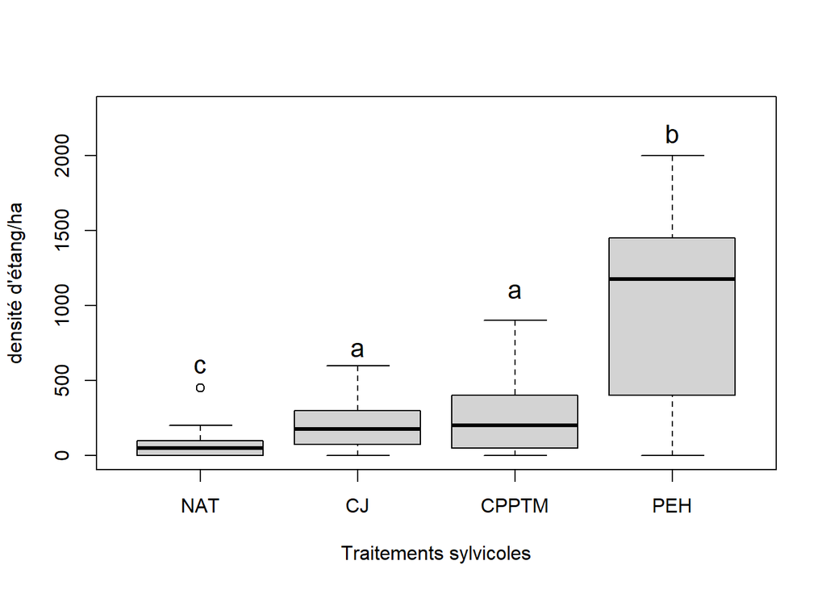

```r
den_a$Coupe <- factor(den_a$Coupe, levels = c("NAT", "CJ", "CPPTM", "PEH"))

boxplot(den_a$densite_ha ~ den_a$Coupe,ylab = "densité d'étang/ha", xlab = "Traitements sylvicoles",ylim=c(0,2300))
text(x = 1, y = 600, labels = "c", cex = 1.3)   # NAT
text(x = 2, y = 710, labels = "a", cex = 1.3)  # CJ
text(x = 3, y = 1100, labels = "a", cex = 1.3)   # CPPTM
text(x = 4, y = 2150, labels = "b", cex = 1.3)  # PEH
```

[output not shown]

C’est clair, les PEH peuvent avoir beaucoup plus d’étangs que les autre types de traitements sylvicoles. Essayons de pousser cela plus loin!

**2.1 Pousser plus loin: Ratios**

J’ai demandé à ChatGPT de me faire un code qui montre combien de fois que la densité d’étangs dans le traitement PEH est plus élevée comparé aux autres:

```r
emm2 <- emmeans(mod3, ~ Coupe)
contrast(emm2,method = list("PEH vs autres" = c(-1/3, -1/3, -1/3, 1)),type = "response")
```

```
 contrast      ratio   SE  df null z.ratio p.value
 PEH vs autres  6.24 1.57 Inf    1   7.290 <0.0001

Tests are performed on the log scale
```

Le ratio de 6.24 signifie que PEH a une densité environ 6.24x plus élevée que les autres traitements.

Avec cet autre calcul et code par ChatGPT on obtient autre choses intéressant.

```r
Pour_log <- emmeans(mod3, ~ Coupe)
Pour <- summary(pairs(Pour_log, type="response", adjust="tukey"))
Pour$percent_change <- (Pour$ratio - 1) * 100
Pour
```

```
 contrast     ratio     SE  df null z.ratio p.value percent_change
 CJ / CPPTM  0.8111 0.2490 Inf    1  -0.682  0.9038          -18.9
 CJ / NAT    3.0357 1.1000 Inf    1   3.073  0.0114          203.6
 CJ / PEH    0.2163 0.0675 Inf    1  -4.907 <0.0001          -78.4
 CPPTM / NAT 3.7429 1.2900 Inf    1   3.841  0.0007          274.3
 CPPTM / PEH 0.2667 0.0777 Inf    1  -4.535 <0.0001          -73.3
 NAT / PEH   0.0712 0.0248 Inf    1  -7.584 <0.0001          -92.9

P value adjustment: tukey method for comparing a family of 4 estimates
Tests are performed on the log scale
```

Plus d’autres calculs également apporté par ChatGPT:

[figure not shown]

On peut estimer que la densité d’étangs dans PEH est environ 14x plus élevé comparé que la densité d’étangs dans NAT.

## MAI: Est-ce que la densité d’étang/ha varie entre les traitements ?

Pour s’assurer que le pattern observé en avril se maintiens à travers le temps, voyons voir si les données prises en fin-mai/juin sont les mêmes.

**1.1 Préparation des données :**

```r
df4 <-read_excel("C:/Users/super/Université du Québec en Outaouais/CLAUDIE ÉTANGS VERNAUX - Documents/Stats/Densité_depression/Data_base_densite.xlsx", sheet = 4)
df4$Coupe <- as.factor(df4$Coupe)
df4$nb_etang_total <- as.numeric(df4$nb_etang_total)
df4 <- df4[-8, ]
df4
```

```
# A tibble: 85 × 14
   Transect   Coupe nb_etang_total orniere orniere_coloni trou_monticule
   <chr>      <fct>          <dbl> <chr>   <chr>          <chr>
 1 WATCJ6     CJ                 5 5       0              0
 2 WATCJ5     CJ                 3 3       1              0
 3 WATCJ1     CJ                NA NA      NA             NA
 4 WATCJ2     CJ                 2 2       0              0
 5 WATCJ4     CJ                 6 5       2              0
 6 WATCJ3     CJ                 3 3       1              0
 7 WATCPPTM10 CPPTM              0 0       0              0
 8 WATCPPTM9  CPPTM              2 2       0              0
 9 WATCPPTM8  CPPTM              0 0       0              0
10 WATCPPTM7  CPPTM             NA NA      NA             NA
# ℹ 75 more rows
# ℹ 8 more variables: trou_coloni <chr>, naturel <chr>, naturel_colo <chr>,
#   nb_colonise_total <chr>, LISY <chr>, AMMA <chr>, LICL <chr>,
#   anoure_sp <chr>
```

```r
den_m <- df4[, c(2, 3)]
den_m$nb_etang_total[is.na(den_m$nb_etang_total)] <- 0
den_m
```

```
# A tibble: 85 × 2
   Coupe nb_etang_total
   <fct>          <dbl>
 1 CJ                 5
 2 CJ                 3
 3 CJ                 0
 4 CJ                 2
 5 CJ                 6
 6 CJ                 3
 7 CPPTM              0
 8 CPPTM              2
 9 CPPTM              0
10 CPPTM              0
# ℹ 75 more rows
```

**1.2 Choix de l’analyse :**

```r
table(den_m$Coupe)
```

```
   CJ CPPTM   NAT   PEH
   20    25    20    20
```

```r
tapply(den_m$nb_etang_total,den_m$Coupe,summary)
```

```
$CJ
   Min. 1st Qu.  Median    Mean 3rd Qu.    Max.
   0.00    0.75    2.50    2.85    4.25    9.00

$CPPTM
   Min. 1st Qu.  Median    Mean 3rd Qu.    Max.
   0.00    0.00    2.00    4.68    6.00   30.00

$NAT
   Min. 1st Qu.  Median    Mean 3rd Qu.    Max.
      0       0       0       0       0       0

$PEH
   Min. 1st Qu.  Median    Mean 3rd Qu.    Max.
   0.00   10.75   21.50   17.75   25.00   30.00
```

Pour NAT, on a une séparation complète puisque ce n’est que des zéros.

```r
mod5 <- aov(den_m$nb_etang_total ~ den_m$Coupe)
shapiro.test(residuals(mod5))
```

```
    Shapiro-Wilk normality test

data:  residuals(mod5)
W = 0.91179, p-value = 2.362e-05
```

Aussi les données ne sont pas normales

```r
leveneTest(den_m$nb_etang_total ~ den_m$Coupe)
```

```
Levene's Test for Homogeneity of Variance (center = median)
      Df F value    Pr(>F)
group  3  9.2012 2.626e-05 ***
      81
---
Signif. codes:  0 '***' 0.001 '**' 0.01 '*' 0.05 '.' 0.1 ' ' 1
```

Ce n’est pas homogène

```r
mod5_2 <- glm(den_m$nb_etang_total ~ den_m$Coupe,family = poisson(link = "log"))
dis <- sum(residuals(mod5_2, type = "pearson")^2) / df.residual(mod5_2)
dis
```

```
[1] 4.91126
```

Un GLM Poisson ne fonctionnerait pas non plus ici, il y a trop de dispersion.  
Encore une fois, on va essayer un modèle binomial négatif.

```r
mod6 <- glm.nb(den_m$nb_etang_total ~ den_m$Coupe)
summary(mod6)
```

```
Call:
glm.nb(formula = den_m$nb_etang_total ~ den_m$Coupe, init.theta = 0.9902947459,
    link = log)

Coefficients:
                  Estimate Std. Error z value Pr(>|z|)
(Intercept)         1.0473     0.2608   4.015 5.94e-05 ***
den_m$CoupeCPPTM    0.4960     0.3420   1.450    0.147
den_m$CoupeNAT    -21.3499  3475.2664  -0.006    0.995
den_m$CoupePEH      1.8291     0.3483   5.251 1.51e-07 ***
---
Signif. codes:  0 '***' 0.001 '**' 0.01 '*' 0.05 '.' 0.1 ' ' 1

(Dispersion parameter for Negative Binomial(0.9903) family taken to be 1)

    Null deviance: 193.235  on 84  degrees of freedom
Residual deviance:  76.731  on 81  degrees of freedom
AIC: 386.53

Number of Fisher Scoring iterations: 1

              Theta:  0.990
          Std. Err.:  0.234

 2 x log-likelihood:  -376.531
```

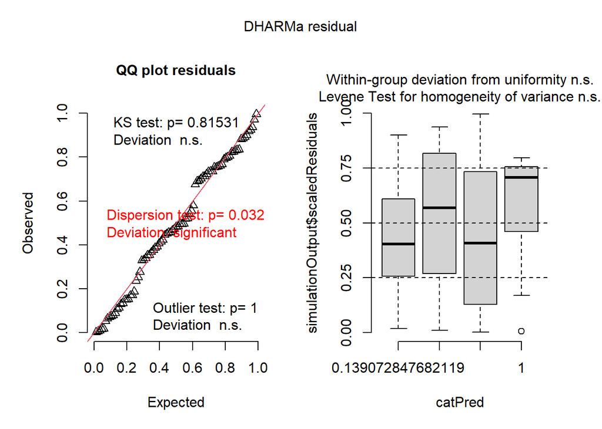

```r
sim2 <- simulateResiduals(mod6)
plot(sim2) #majoritairement super bon
```

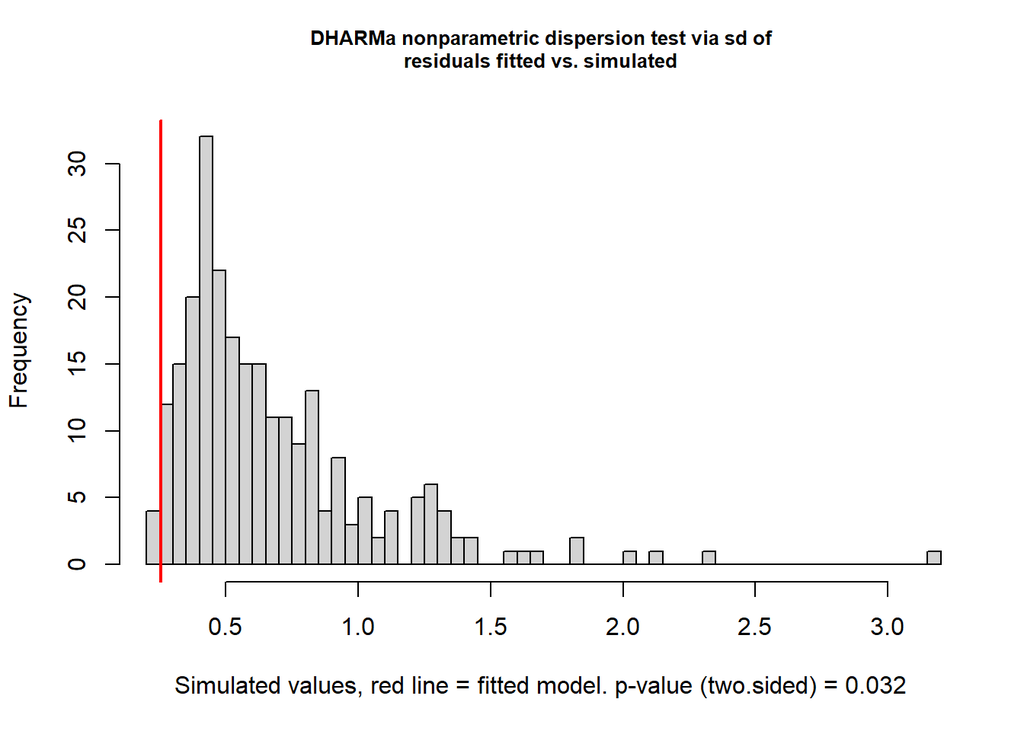

```
    DHARMa nonparametric dispersion test via sd of residuals fitted vs.
    simulated

data:  simulationOutput
dispersion = 0.37644, p-value = 0.032
alternative hypothesis: two.sided
```

```r
testDispersion(sim2) #Presque ok mais pas parfait
```

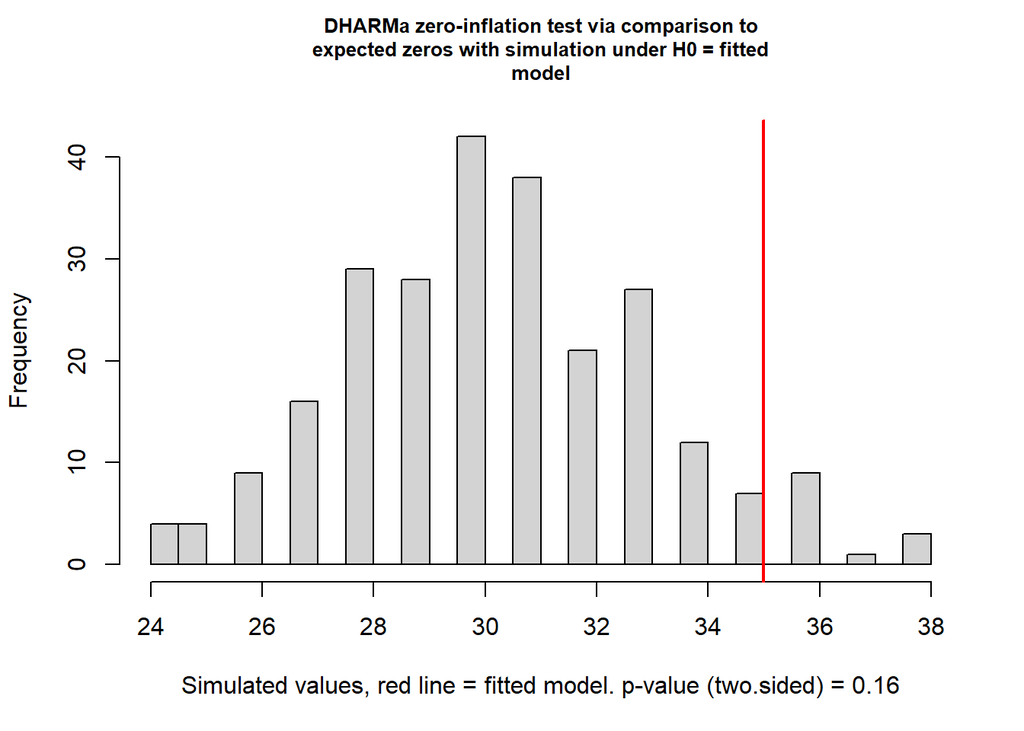

```
    DHARMa zero-inflation test via comparison to expected zeros with
    simulation under H0 = fitted model

data:  simulationOutput
ratioObsSim = 1.149, p-value = 0.16
alternative hypothesis: two.sided
```

```r
testZeroInflation(sim2) #ok
```

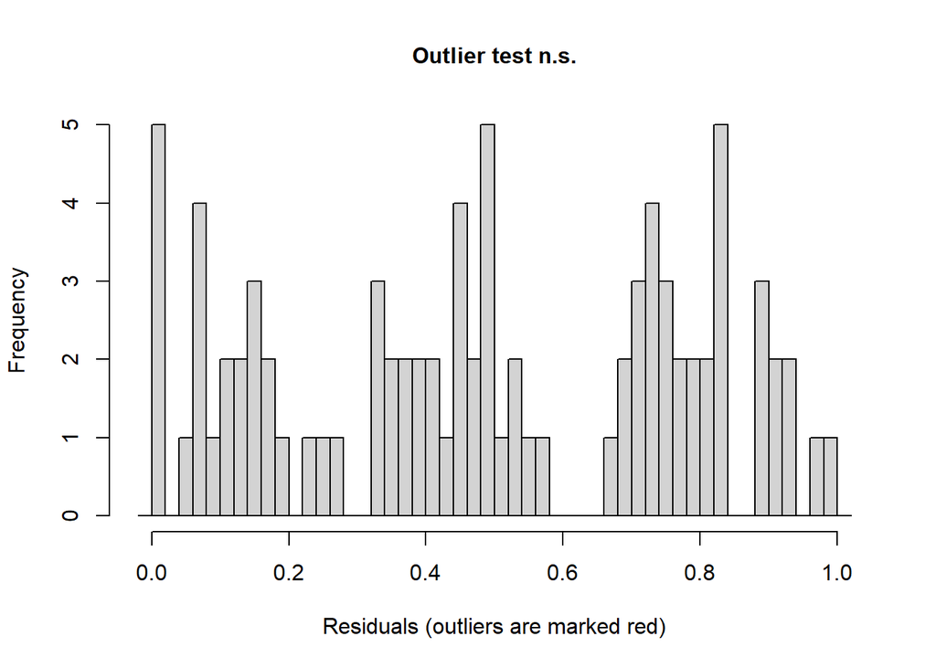

```
    DHARMa bootstrapped outlier test

data:  sim2
outliers at both margin(s) = 0, observations = 85, p-value = 1
alternative hypothesis: two.sided
 percent confidence interval:
 0.00000000 0.02352941
sample estimates:
outlier frequency (expected: 0.00482352941176471 )
                                                 0
```

```r
testOutliers(sim2) #ok
```

Ici, le modèle est presque parfait mais la dispersion est un peu problématique ce qui est probablement causé par la séparation de NAT. Par contre, puisque tout le reste est bon, on va continuer. Il faura toutefois eviter un post-hoc avec emmeans car cela donnera des résultats non fiable à cause de la séparation de NAT.

**1.3 Analyse :** **Modèle Binomial négatif**

```r
anova(mod6, test = "Chisq")
```

```
Analysis of Deviance Table

Model: Negative Binomial(0.9903), link: log

Response: den_m$nb_etang_total

Terms added sequentially (first to last)

            Df Deviance Resid. Df Resid. Dev  Pr(>Chi)
NULL                           84    193.235
den_m$Coupe  3    116.5        81     76.731 < 2.2e-16 ***
---
Signif. codes:  0 '***' 0.001 '**' 0.01 '*' 0.05 '.' 0.1 ' ' 1
```

C’est significatif, au moins un traitement sylvicole a une densité d’étang qui diffère des autres.

**1.4 Post-Hoc: Test du rapport de vraisemblance ‘’à la main’’ + Wilcoxon**

NAT cause problème, alors faire des test par pair un à un va éviter d’obtenir des résultats non fiables. Le rapport de vraisemblence sera effectué à l’aide d’une fonction créée par ChatGPT. Par contre, tout les paires qui on NAT seron comparés avec le test de Wilcoxon pour tout de même comparer la densité d’étangs des deux traitements sylvicoles en évitant de se relier sur la variabilité inexistante dans NAT. Une fois chaque p-value obtenue, la correction de Holm sera appliqué:

```r
# Fonction pour comparer deux traitements
comparaison_NB <- function(data, groupe1, groupe2){

  # garder seulement les deux groupes
  df <- subset(data, Coupe %in% c(groupe1, groupe2))

  # remettre le facteur à zéro
  df$Coupe <- droplevels(df$Coupe)

  # modèle avec traitement
  mod_complet <- glm.nb(nb_etang_total ~ Coupe, data = df)

  # modèle sans traitement
  mod_nul <- glm.nb(nb_etang_total ~ 1, data = df)

  # test du rapport de vraisemblance
  resultat <- anova(mod_nul, mod_complet, test = "Chisq")

  return(resultat)
}

# Comparaisons
#Notes, puisque NAT a une séparation complète, un test de wilcox est plus approprié

comparaison_NB(den_m, "CJ", "CPPTM") #0.2339578
```

```
Likelihood ratio tests of Negative Binomial Models

Response: nb_etang_total
  Model     theta Resid. df    2 x log-lik.   Test    df LR stat.   Pr(Chi)
1     1 0.6089559        44       -219.1598
2 Coupe 0.6377006        43       -217.7432 1 vs 2     1 1.416637 0.2339578
```

```r
wilcox.test(nb_etang_total ~ Coupe,data = subset(den_m, Coupe %in% c("CJ","NAT")),exact = FALSE)
```

```
    Wilcoxon rank sum test with continuity correction

data:  nb_etang_total by Coupe
W = 350, p-value = 3.257e-06
alternative hypothesis: true location shift is not equal to 0
```

```r
                                     #3.257e-06
comparaison_NB(den_m, "CJ", "PEH")   #3.720458e-08
```

```
Likelihood ratio tests of Negative Binomial Models

Response: nb_etang_total
  Model     theta Resid. df    2 x log-lik.   Test    df LR stat.      Pr(Chi)
1     1 0.7709908        39       -269.1935
2 Coupe 2.2116222        38       -238.9035 1 vs 2     1 30.28996 3.720458e-08
```

```r
wilcox.test(nb_etang_total ~ Coupe,data = subset(den_m, Coupe %in% c("CPPTM","NAT")),exact = FALSE)
```

```
    Wilcoxon rank sum test with continuity correction

data:  nb_etang_total by Coupe
W = 410, p-value = 2.033e-05
alternative hypothesis: true location shift is not equal to 0
```

```r
                                     #2.033e-05
comparaison_NB(den_m, "CPPTM", "PEH")#0.000294576
```

```
Likelihood ratio tests of Negative Binomial Models

Response: nb_etang_total
  Model     theta Resid. df    2 x log-lik.   Test    df LR stat.     Pr(Chi)
1     1 0.6150304        44       -301.2720
2 Coupe 0.8998450        43       -288.1675 1 vs 2     1 13.10457 0.000294576
```

```r
wilcox.test(nb_etang_total ~ Coupe,data = subset(den_m, Coupe %in% c("NAT","PEH")),exact = FALSE)
```

```
    Wilcoxon rank sum test with continuity correction

data:  nb_etang_total by Coupe
W = 10, p-value = 2.976e-08
alternative hypothesis: true location shift is not equal to 0
```

```r
                                     #2.976e-08
#correction:
p.adjust(c(0.2339578,3.257e-06,3.720458e-08,2.033e-05,0.000294576,2.976e-08), method = "holm")
```

```
[1] 2.339578e-01 1.302800e-05 1.860229e-07 6.099000e-05 5.891520e-04
[6] 1.785600e-07
```

```r
#RÉSULTATS

#CJ-CPPTM:0.2339578
#CJ-NAT: 1.302800e-05
#CJ-PEH: 1.860229e-07
#CPPTM-NAT: 6.099000e-05
#CPPTM-PEH:5.891520e-04
#NAT-PEH:1.785600e-07
```

Ici, c’est seulement CJ-CPPTM ne diffèrent pas significativement

**1.5 Visualisation**

Tout comme pour le mois d’avril, la densité en étang est transformée pour que ce soit ‘’étangs/ha’’

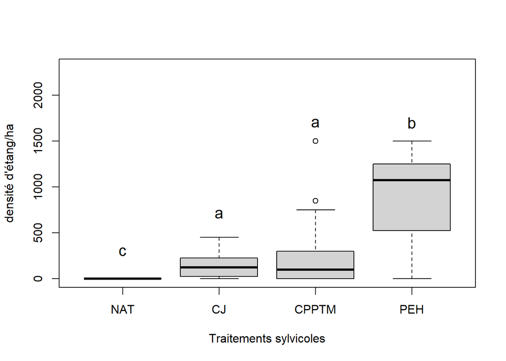

```r
den_m$densite_ha <- den_m$nb_etang_total * 50 #ça transforme en ''etang/ha''
den_m$Coupe <- factor(den_m$Coupe, levels = c("NAT", "CJ", "CPPTM", "PEH"))

boxplot(den_m$densite_ha ~ den_m$Coupe,ylab = "densité d'étang/ha", xlab = "Traitements sylvicoles",ylim=c(0,2300))
text(x = 1, y = 300, labels = "c", cex = 1.3)   # NAT
text(x = 2, y = 710, labels = "a", cex = 1.3)  # CJ
text(x = 3, y = 1700, labels = "a", cex = 1.3)   # CPPTM
text(x = 4, y = 1700, labels = "b", cex = 1.3)  # PEH
```

| n NAT = 20 n CJ = 20 | n CPPTM = 26 n PEH = 20 |
| --- | --- |

**2.1** **Pousser plus loin: Ratios**

Puisque la séparation causée par NAT rend tout ratio utilisant NAT impossible (on ne peux pas diviser zéro), on ne peux pas pousser les analyses plus loin comme je l’ai fait avec les données du mois d’avril. Il faut donc laisser tomber cet aspect.

## La densité d’étangs diminue-t-elle significativement entre avril et mai, toutes coupes confondues ?

Il semble y avoir une différence entre avril et mai: la densité d’étangs dans la majorité des traitements silvicoles semble diminuer. Toutefois, c’est mieux de confirmer cela statistiquement. Donc, toute coupes confondues, est-ce qu’on voit vraiment une diminution dans le temps?

1. **Préparation des données :**

   Ici, faut faire une base de donnée sans coupe précises mais on garde chaque transects

   ```r
   library(dplyr)
   avril <-read_excel("C:/Users/super/Université du Québec en Outaouais/CLAUDIE ÉTANGS VERNAUX - Documents/Stats/Densité_depression/Bases_de_donnees/Data_base_avril.xlsx", sheet = 1)
   avril <- avril %>% rename(a_etang_total = etang_total)
   avril
   ```

   ```
   # A tibble: 85 × 6
      Transect   Coupe a_etang_total orniere trou_monticule naturel
      <chr>      <chr>         <dbl> <chr>   <chr>          <chr>
    1 WATCJ6     CJ              450 350     0              100
    2 WATCJ5     CJ              150 150     0              0
    3 WATCJ1     CJ                0 0       0              0
    4 WATCJ2     CJ               50 50      0              0
    5 WATCJ4     CJ              500 450     0              50
    6 WATCJ3     CJ              100 100     0              0
    7 WATCPPTM10 CPPTM           100 100     0              0
    8 WATCPPTM9  CPPTM            50 50      0              0
    9 WATCPPTM8  CPPTM            50 50      0              0
   10 WATCPPTM7  CPPTM            50 50      0              0
   # ℹ 75 more rows
   ```

   ```r
   mai <- read_excel("C:/Users/super/Université du Québec en Outaouais/CLAUDIE ÉTANGS VERNAUX - Documents/Stats/Densité_depression/Bases_de_donnees/Data_base_avril.xlsx", sheet = 2)
   mai <- mai %>% rename(m_etang_total = etang_total)
   mai
   ```

   ```
   # A tibble: 85 × 6
      Transect   Coupe m_etang_total orniere trou_monticule naturel
      <chr>      <chr>         <dbl>   <dbl>          <dbl>   <dbl>
    1 WATCJ6     CJ              250     250              0       0
    2 WATCJ5     CJ              150     150              0       0
    3 WATCJ1     CJ                0       0              0       0
    4 WATCJ2     CJ              100     100              0       0
    5 WATCJ4     CJ              300     250              0      50
    6 WATCJ3     CJ              150     150              0       0
    7 WATCPPTM10 CPPTM             0       0              0       0
    8 WATCPPTM9  CPPTM           100     100              0       0
    9 WATCPPTM8  CPPTM             0       0              0       0
   10 WATCPPTM7  CPPTM             0       0              0       0
   # ℹ 75 more rows
   ```

   ```r
   df3 <- avril %>% dplyr::select(Transect, a_etang_total) %>%
     dplyr::left_join(mai %>% dplyr::select(Transect, m_etang_total),by = "Transect")
   df3
   ```

   ```
   # A tibble: 85 × 3
      Transect   a_etang_total m_etang_total
      <chr>              <dbl>         <dbl>
    1 WATCJ6               450           250
    2 WATCJ5               150           150
    3 WATCJ1                 0             0
    4 WATCJ2                50           100
    5 WATCJ4               500           300
    6 WATCJ3               100           150
    7 WATCPPTM10           100             0
    8 WATCPPTM9             50           100
    9 WATCPPTM8             50             0
   10 WATCPPTM7             50             0
   # ℹ 75 more rows
   ```

2. **Choix de l’analyse**

   Pour répondre à la question il faut prendre en concidération qu’on va comparer des données dépendantes puisque les étangs ont été comptés sur les mêmes transectes, juste à des moments différents (avril et mai). Ceci limite le type de test que l’on peut effectuer

   ```r
   dif <- df3$a_etang_total - df3$m_etang_total
   shapiro.test(dif)
   ```

   ```
       Shapiro-Wilk normality test

   data:  dif
   W = 0.8188, p-value = 7.95e-09
   ```

   De plus les données ne sont pas du tout normales.

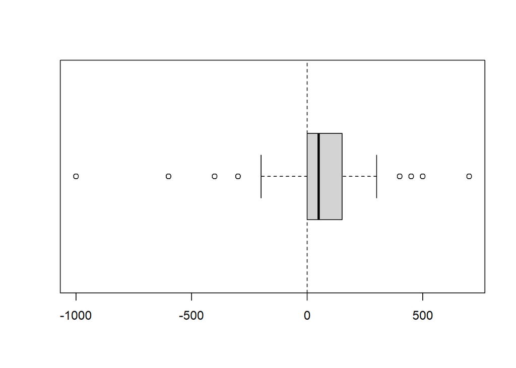

   ```r
   boxplot(dif, horizontal = TRUE)
   abline(v = 0, lty = 2)
   ```

   Et ici, le graphique démontre qu’il semblerait effectivement avoir plus d’étangs en avril puisque la majorité des données se trouvent à la droite du 0. Une analyse de Wilcoxon permet de prendre en compte toutes ces composantes.
3. **Analyse**

   ```r
   wilcox.test(df3$a_etang_total, df3$m_etang_total, paired = TRUE,alternative = "greater")
   ```

   ```
       Wilcoxon signed rank test with continuity correction

   data:  df3$a_etang_total and df3$m_etang_total
   V = 1648, p-value = 2.126e-05
   alternative hypothesis: true location shift is greater than 0
   ```

   Très significatif, il y a clairement plus d’étangs en avril qu’en mai!
4. **Visualisation**

   ```r
   library(ggplot2)
   avril2 <- read_excel("C:/Users/super/Université du Québec en Outaouais/CLAUDIE ÉTANGS VERNAUX - Documents/Stats/Densité_depression/Bases_de_donnees/Data_base_avril.xlsx", sheet = 1)
   avril2$Temps <- 'Avril'


   mai2 <- read_excel("C:/Users/super/Université du Québec en Outaouais/CLAUDIE ÉTANGS VERNAUX - Documents/Stats/Densité_depression/Bases_de_donnees/Data_base_avril.xlsx", sheet = 2)
   mai2$Temps <- 'Mai'

   pertes <- read_excel("C:/Users/super/Université du Québec en Outaouais/CLAUDIE ÉTANGS VERNAUX - Documents/Stats/Densité_depression/Bases_de_donnees/Data_base_avril.xlsx", sheet = 3)
   pertes
   ```

   ```
   # A tibble: 85 × 6
      Transect   Coupe Pertes orniere trou_monticule naturel
      <chr>      <chr>  <dbl> <chr>   <chr>          <chr>
    1 WATCJ6     CJ       200 100     0              100
    2 WATCJ5     CJ         0 0       0              0
    3 WATCJ1     CJ         0 0       0              0
    4 WATCJ2     CJ       -50 -50     0              0
    5 WATCJ4     CJ       200 200     0              0
    6 WATCJ3     CJ       -50 -50     0              0
    7 WATCPPTM10 CPPTM    100 100     0              0
    8 WATCPPTM9  CPPTM    -50 -50     0              0
    9 WATCPPTM8  CPPTM     50 50      0              0
   10 WATCPPTM7  CPPTM     50 50      0              0
   # ℹ 75 more rows
   ```

   ```r
   df2 <- rbind(avril2, mai2)
   df2$Temps <- factor(df2$Temps)
   df2$Coupe <- factor(df2$Coupe)
   df2$Transect <- factor(df2$Transect)
   pertes$trend <- ifelse(pertes$Pertes > 0, "Perte",ifelse(pertes$Pertes < 0, "Gain", "Stable"))
   df2 <- merge(df2, pertes[, c("Transect", "trend")], by = "Transect")
   df2
   ```

   ```
         Transect Coupe etang_total orniere trou_monticule naturel Temps  trend
   1       DORCJ1    CJ           0       0              0       0   Mai  Perte
   2       DORCJ1    CJ          50      NA             NA      NA Avril  Perte
   3      DORCJ10    CJ         150      NA             NA      NA Avril  Perte
   4      DORCJ10    CJ           0       0              0       0   Mai  Perte
   5      DORCJ11    CJ         350     350              0       0 Avril  Perte
   6      DORCJ11    CJ         300     300              0       0   Mai  Perte
   7      DORCJ12    CJ         200     200              0       0 Avril  Perte
   8      DORCJ12    CJ         150     150              0       0   Mai  Perte
   9      DORCJ13    CJ          50      50              0       0   Mai Stable
   10     DORCJ13    CJ          50      50              0       0 Avril Stable
   11     DORCJ14    CJ         100     100              0       0 Avril  Perte
   12     DORCJ14    CJ          50      50              0       0   Mai  Perte
   13      DORCJ2    CJ         250      NA             NA      NA Avril  Perte
   14      DORCJ2    CJ         200     200              0       0   Mai  Perte
   ```

   [output cut: 156 more lines]

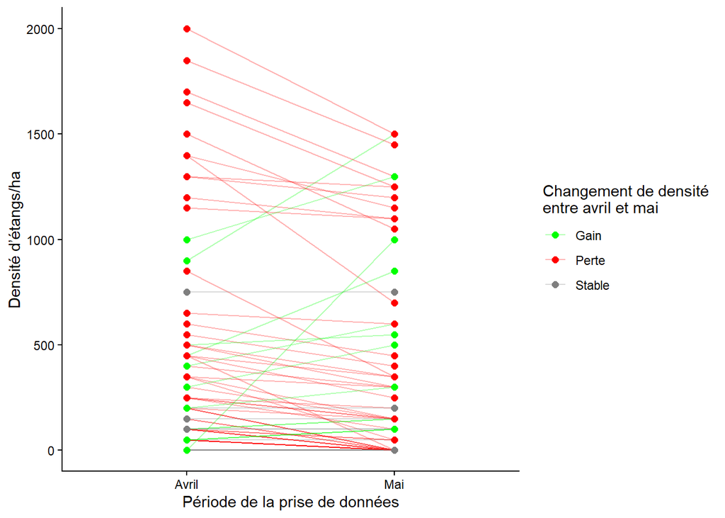

   ```r
          #Plot
   ggplot(df2, aes(x = Temps, y = etang_total, group = Transect, colour = trend)) +
     geom_line(alpha = 0.3) +
     geom_point(size = 2) +
     scale_colour_manual(values = c("Gain" = "green","Perte" = "red","Stable" = "grey50")) +
     theme_classic()+
     labs(x = "Période de la prise de données",y = "Densité d’étangs/ha")+
     labs(colour = "Changement de densité\nentre avril et mai")
   ```

   | n NAT = 20 n CJ = 20 | n CPPTM = 26 n PEH = 20 |
   | --- | --- |

5. **Conclusion**

## La perte d’étangs entre avril et mai diffère-t-elle selon le traitement ?

On sait qu’il y a une diminution significative, mais est-ce que celle-ci diffère entre les types de traitements sylvicoles?

1. **Préparation des données :**

   ```r
   avril <-read_excel("C:/Users/super/Université du Québec en Outaouais/CLAUDIE ÉTANGS VERNAUX - Documents/Stats/Densité_depression/Data_base_densite.xlsx", sheet = 1)
   avril <- avril %>%
     dplyr::select(Transect, Coupe, nb_etang_total) %>%
     dplyr::rename(etang_total=nb_etang_total)
   avril$Mois <- 'Avril'
   avril
   ```

   ```
   # A tibble: 86 × 4
      Transect   Coupe etang_total Mois
      <chr>      <chr> <chr>       <chr>
    1 WATCJ6     CJ    9           Avril
    2 WATCJ5     CJ    3           Avril
    3 WATCJ1     CJ    0           Avril
    4 WATCJ2     CJ    1           Avril
    5 WATCJ4     CJ    10          Avril
    6 WATCJ3     CJ    2           Avril
    7 WATCPPTM10 CPPTM 2           Avril
    8 WATCPPTM11 CPPTM NA          Avril
    9 WATCPPTM9  CPPTM 1           Avril
   10 WATCPPTM8  CPPTM 1           Avril
   # ℹ 76 more rows
   ```

   ```r
   mai <- read_excel("C:/Users/super/Université du Québec en Outaouais/CLAUDIE ÉTANGS VERNAUX - Documents/Stats/Densité_depression/Data_base_densite.xlsx", sheet = 4)
   mai <- mai %>%
     dplyr::select(Transect, Coupe, nb_etang_total) %>%
     dplyr::rename(etang_total=nb_etang_total)
   mai$Mois <- 'Mai'
   mai
   ```

   ```
   # A tibble: 86 × 4
      Transect   Coupe etang_total Mois
      <chr>      <chr> <chr>       <chr>
    1 WATCJ6     CJ    5           Mai
    2 WATCJ5     CJ    3           Mai
    3 WATCJ1     CJ    NA          Mai
    4 WATCJ2     CJ    2           Mai
    5 WATCJ4     CJ    6           Mai
    6 WATCJ3     CJ    3           Mai
    7 WATCPPTM10 CPPTM 0           Mai
    8 WATCPPTM11 CPPTM 1           Mai
    9 WATCPPTM9  CPPTM 2           Mai
   10 WATCPPTM8  CPPTM 0           Mai
   # ℹ 76 more rows
   ```

   ```r
   df<-bind_rows(avril, mai)
   df$etang_total <- as.numeric(df$etang_total)
   df$etang_total[is.na(df$etang_total)] <- 0
   df <- df %>% mutate(Transect = factor(Transect),Coupe = factor(Coupe), Mois = factor(Mois, levels = c("Avril", "Mai")))
   df
   ```

   ```
   # A tibble: 172 × 4
      Transect   Coupe etang_total Mois
      <fct>      <fct>       <dbl> <fct>
    1 WATCJ6     CJ              9 Avril
    2 WATCJ5     CJ              3 Avril
    3 WATCJ1     CJ              0 Avril
    4 WATCJ2     CJ              1 Avril
    5 WATCJ4     CJ             10 Avril
    6 WATCJ3     CJ              2 Avril
    7 WATCPPTM10 CPPTM           2 Avril
    8 WATCPPTM11 CPPTM           0 Avril
    9 WATCPPTM9  CPPTM           1 Avril
   10 WATCPPTM8  CPPTM           1 Avril
   # ℹ 162 more rows
   ```

2. **Choix de l’analyse**

   Ici on a des données qui découlent de mesures répétées sur le même transect avec des valeurs positives, négatives et nules (zéro). Le nombre d’étangs est une variable de comptage probablement non normalement distribuées. Ainsi, un glmmTMB serait intéressant ici.  
   Il faut faire un peu plus de test pour choisir la bonne famille pour le modèle:

   ```r
   summary(df$etang_total) #distribution est assez asymétrique (median 2 alors que mean 6.785)
   ```

   ```
      Min. 1st Qu.  Median    Mean 3rd Qu.    Max.
     0.000   0.000   2.000   6.785   9.000  40.000
   ```

   ```r
   mean(df$etang_total)
   ```

   ```
   [1] 6.784884
   ```

   ```r
   var(df$etang_total) #variance n'est pas égal à la moyenne, la famille poisson n'est pas préférable. Surdispersion potentiel
   ```

   ```
   [1] 88.36866
   ```

   ```r
   mean(df$etang_total == 0) #beaucoup de zéros dans la base de données mais juste 30%. nbnom peut le prendre
   ```

   ```
   [1] 0.3023256
   ```

   La distribution est asymétrique (médian = 2 alors que moyenne = 6.786.  
   La variance n’est pas égale à la moyenne, ceci suggeste une sudispersion donc la famille Poisson n’est pas idéal. Par contre la famille Negative Binomial serait intéressant.  
   Il y a présence de zéros, mais à environ 30%, le modèle devrait pouvoir fonctionner sans avoir besoin d’utiliser le zero inflation.
3. **Analyse**

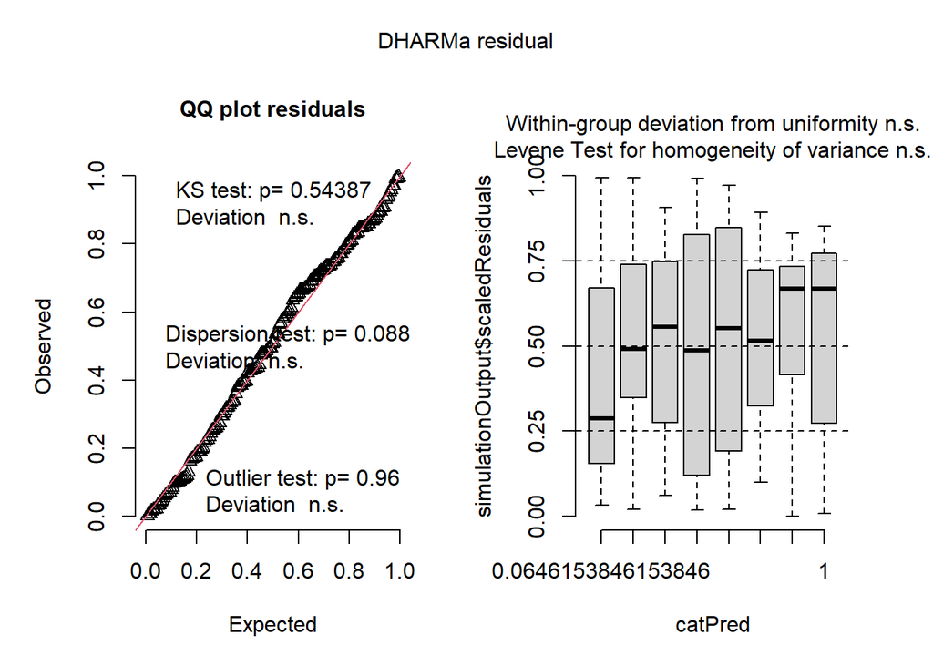

   ```r
   library(glmmTMB)
   library(DHARMa)
   mod_nb1 <- glmmTMB(etang_total ~ Mois * Coupe + (1 | Transect),family = nbinom1,data = df)
   res_nb1 <- simulateResiduals(mod_nb1)
   plot(res_nb1) #ok
   ```

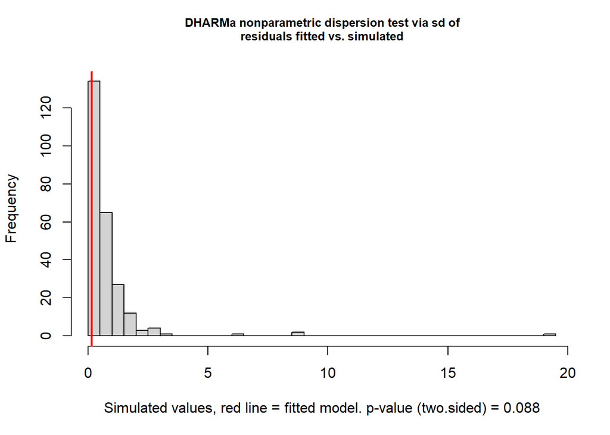

   ```
       DHARMa nonparametric dispersion test via sd of residuals fitted vs.
       simulated

   data:  simulationOutput
   dispersion = 0.1797, p-value = 0.088
   alternative hypothesis: two.sided
   ```

   ```r
   testDispersion(res_nb1) #ok
   ```

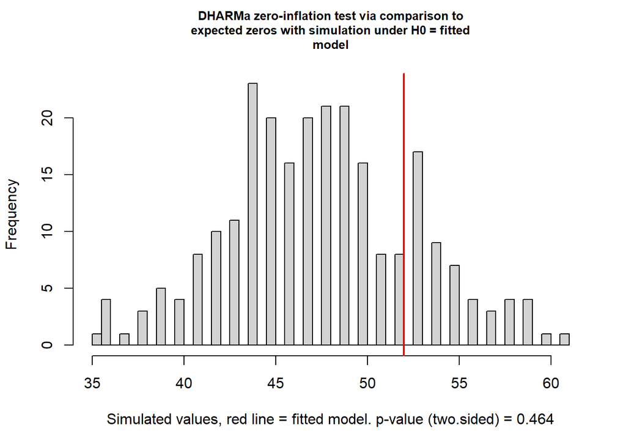

   ```
       DHARMa zero-inflation test via comparison to expected zeros with
       simulation under H0 = fitted model

   data:  simulationOutput
   ratioObsSim = 1.0914, p-value = 0.464
   alternative hypothesis: two.sided
   ```

   ```r
   testZeroInflation(res_nb1) #ok
   ```

   Les analyses de DHARMa montre que ce modèle est fonctionnel.

   ```r
   library(car)
   Anova(mod_nb1, type = 2)
   ```

   ```
   Analysis of Deviance Table (Type II Wald chisquare tests)

   Response: etang_total
                Chisq Df Pr(>Chisq)
   Mois        4.1746  1    0.04103 *
   Coupe      56.8110  3   2.82e-12 ***
   Mois:Coupe  2.0314  3    0.56591
   ---
   Signif. codes:  0 '***' 0.001 '**' 0.01 '*' 0.05 '.' 0.1 ' ' 1
   ```

   Ici, le résultats que l’on recherche, Mois:Coupe, n’est pas significatif. Ainsi, les étangs ne sèchent pas significativement plus rapidement d’un traitement à l’autre.
4. **Visualisation**

   ```r
   library(tidyr)
   df_perte <- df %>%
     dplyr::select(Transect, Coupe, Mois, etang_total) %>%
     pivot_wider(names_from = Mois,values_from = etang_total) %>%
     dplyr::mutate(perte = Avril - Mai,perte_ha = perte * 50)
   df_perte
   ```

   ```
   # A tibble: 86 × 6
      Transect   Coupe Avril   Mai perte perte_ha
      <fct>      <fct> <dbl> <dbl> <dbl>    <dbl>
    1 WATCJ6     CJ        9     5     4      200
    2 WATCJ5     CJ        3     3     0        0
    3 WATCJ1     CJ        0     0     0        0
    4 WATCJ2     CJ        1     2    -1      -50
    5 WATCJ4     CJ       10     6     4      200
    6 WATCJ3     CJ        2     3    -1      -50
    7 WATCPPTM10 CPPTM     2     0     2      100
    8 WATCPPTM11 CPPTM     0     1    -1      -50
    9 WATCPPTM9  CPPTM     1     2    -1      -50
   10 WATCPPTM8  CPPTM     1     0     1       50
   # ℹ 76 more rows
   ```

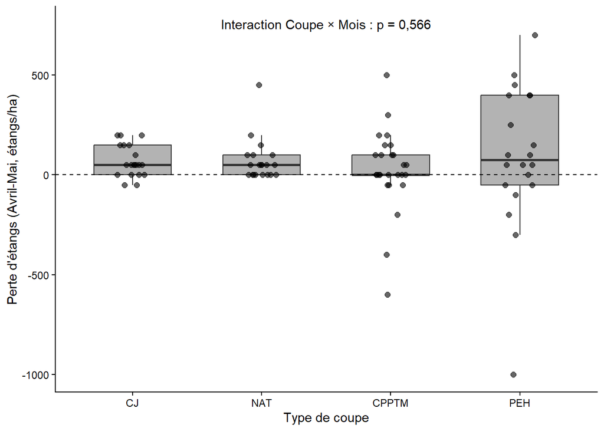

   ```r
   df_perte$Coupe <- factor(df_perte$Coupe,levels = c("CJ", "NAT", "CPPTM", "PEH"))

   ggplot(df_perte, aes(x = Coupe, y = perte_ha)) +
     geom_boxplot(width = 0.6, outlier.shape = NA, fill = "grey70") +
     geom_hline(yintercept = 0,linetype = "dashed")+
     geom_jitter(width = 0.12,height = 0,alpha = 0.6,size = 2) +
     annotate("text",x = 2.5,y = max(df_perte$perte_ha, na.rm = TRUE) * 1.08,label = "Interaction Coupe × Mois : p = 0,566") +
     labs(x = "Type de coupe",y = "Perte d'étangs (Avril-Mai, étangs/ha)") +
     theme_classic()
   ```

   | n NAT = 20 n CJ = 20 | n CPPTM = 26 n PEH = 20 |
   | --- | --- |

   Voici une version plus complète. Ça nous permet de voir que, généralement, la diminution entre avril et mai ne semble pas tant varier selon le type de traitement:

   ```r
   df_plot2 <- df %>%mutate(densite_ha = etang_total * 50,Coupe = factor(Coupe, levels = c("NAT", "CJ", "CPPTM", "PEH")),Mois = factor(Mois, levels = c("Avril", "Mai")))
   df_plot2
   ```

   ```
   # A tibble: 172 × 5
      Transect   Coupe etang_total Mois  densite_ha
      <fct>      <fct>       <dbl> <fct>      <dbl>
    1 WATCJ6     CJ              9 Avril        450
    2 WATCJ5     CJ              3 Avril        150
    3 WATCJ1     CJ              0 Avril          0
    4 WATCJ2     CJ              1 Avril         50
    5 WATCJ4     CJ             10 Avril        500
    6 WATCJ3     CJ              2 Avril        100
    7 WATCPPTM10 CPPTM           2 Avril        100
    8 WATCPPTM11 CPPTM           0 Avril          0
    9 WATCPPTM9  CPPTM           1 Avril         50
   10 WATCPPTM8  CPPTM           1 Avril         50
   # ℹ 162 more rows
   ```

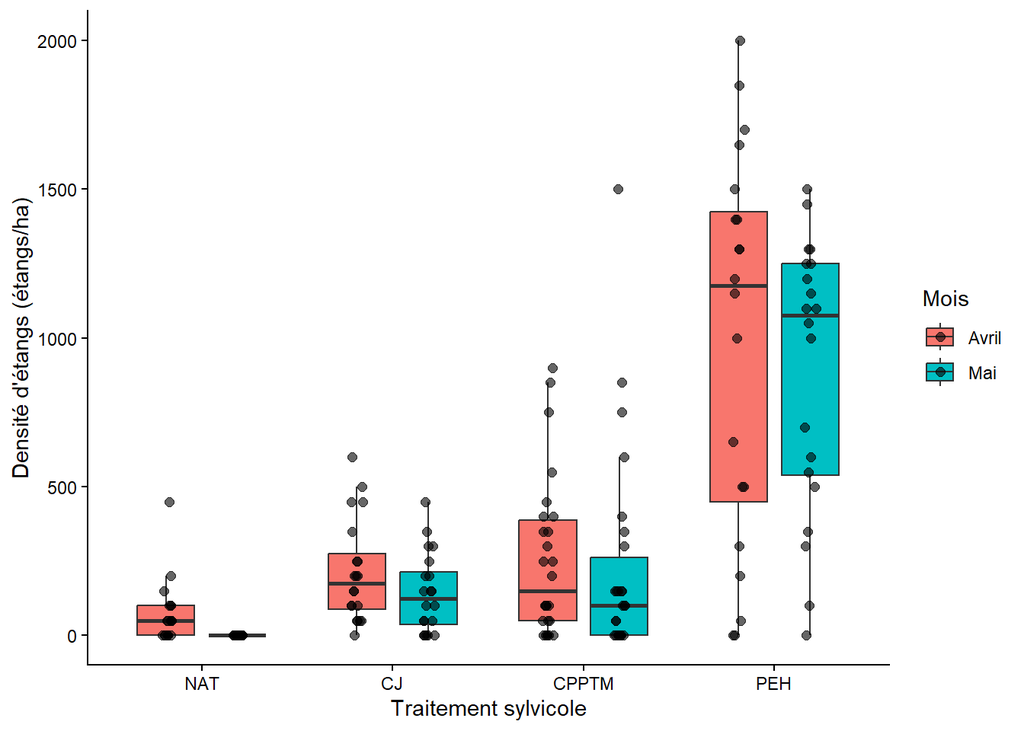

   ```r
   ggplot(df_plot2, aes(x = Coupe, y = densite_ha, fill = Mois)) +
     # Boîtes
     geom_boxplot(position = position_dodge(width = 0.75),width = 0.6,outlier.shape = NA) +
     # Points individuels
     geom_jitter(aes(group = Mois),position = position_jitterdodge(jitter.width = 0.12,dodge.width = 0.75),size = 2,alpha = 0.6) +
     labs(x = "Traitement sylvicole",y = "Densité d'étangs (étangs/ha)",fill = "Mois" ) +
     theme_classic()
   ```

5. **Conclusion**

   Bien qu’il a été confirmé qu’il y a une perte significative d’étangs entre avril et mai, le type de traitement ne semble pas affecter significativement le nombre d’étangs perdu dans le temps.

## Pourcentage de colonisation des étangs

En mai, le nombre d’étangs total a été compilé pour chaque traitement. Parmis ces étangs, chaque étang qui était colonisé par les amphibiens (présence d’oeufs) ont été comptés.

[output not shown]

Un autre tableau a été effectué pour voir le pourcentage d’espèce présente dans chaque étang colonisé selon le traitement.

| Traitement | LISY | Ambystome | LICL (compétition) |
| --- | --- | --- | --- |
| PEH (n=20) | 60.00% | 5.71% | 17.14% |
| CPPTM (n=26) | 100.00% | 8.33% | 25.00% |
| CJ (n=20) | 22.11% | 100.00% | 0.00% |
| NAT (n=20) | 0.00% | 0.00% | 0.00% |